# Travel Package Purchase Prediction

## ProdTaken Vs Preferred Property Star

```
ProdTaken                 0    1   All
PreferredPropertyStar
3.0                    2514  486  3000
4.0                     730  182   912
5.0                     702  249   951
All                    3946  917  4863
------------------------------------------------------------------------------------------------------------------------
```

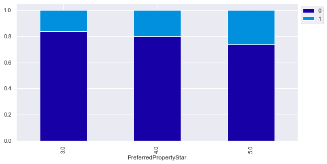

```python
stacked_plot(df['PreferredPropertyStar'])
```

## ProdTaken Vs Number of Trips

```
ProdTaken         0    1   All
NumberOfTrips
1.0             502  112   614
2.0            1157  299  1456
3.0             987  229  1216
4.0             415   60   475
5.0             394   62   456
6.0             257   64   321
7.0             156   60   216
8.0              76   29   105
19.0              0    1     1
20.0              0    1     1
21.0              1    0     1
22.0              1    0     1
All            3946  917  4863
------------------------------------------------------------------------------------------------------------------------
```

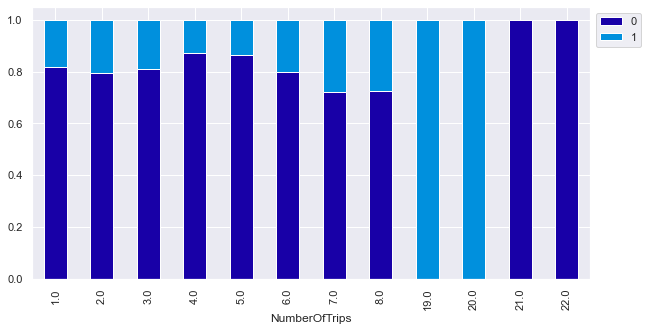

```python
stacked_plot(df['NumberOfTrips'])
```

```
ProdTaken     0    1   All
Passport
0          3018  423  3441
1           928  494  1422
All        3946  917  4863
------------------------------------------------------------------------------------------------------------------------
```

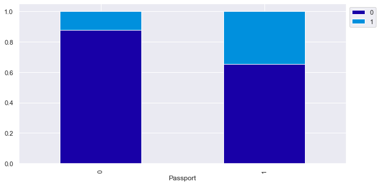

```python
stacked_plot(df['Passport'])
```

### Observation

1. Almost equal amount of customers who have and do not have passport subscribe to the new product

```
ProdTaken                  0    1   All
PitchSatisfactionScore
1                        794  143   937
2                        495   88   583
3                       1152  314  1466
4                        748  162   910
5                        757  210   967
All                     3946  917  4863
------------------------------------------------------------------------------------------------------------------------
```

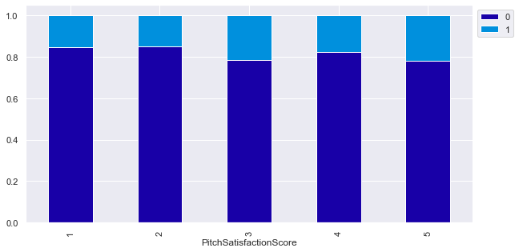

```python
stacked_plot(df['PitchSatisfactionScore'])
```

### Observation,

1. Pitch satisfcation score of 3 purchased the product more

```
ProdTaken     0    1   All
OwnCar
0          1486  359  1845
1          2460  558  3018
All        3946  917  4863
------------------------------------------------------------------------------------------------------------------------
```

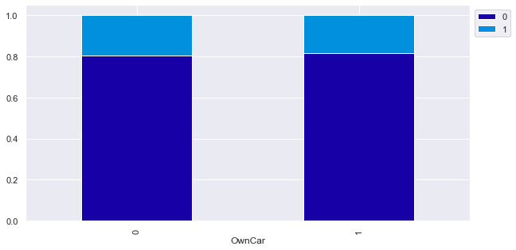

```python
stacked_plot(df['OwnCar'])
```

### Observation.

1. Customers who own cars purchased more wellness package than those who dont have cars

```
ProdTaken                    0    1   All
NumberOfChildrenVisiting
0.0                        870  200  1070
1.0                       1737  398  2135
2.0                       1080  253  1333
3.0                        259   66   325
All                       3946  917  4863
------------------------------------------------------------------------------------------------------------------------
```

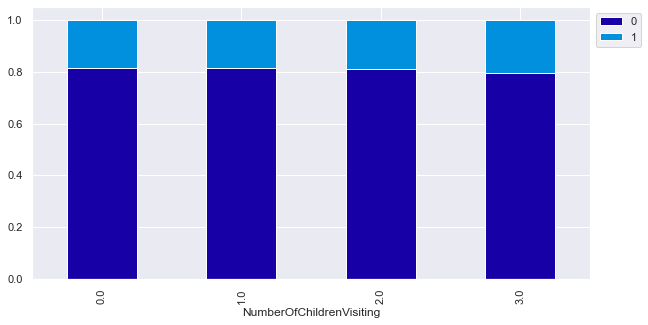

```python
stacked_plot(df['NumberOfChildrenVisiting'])
```

### Observation

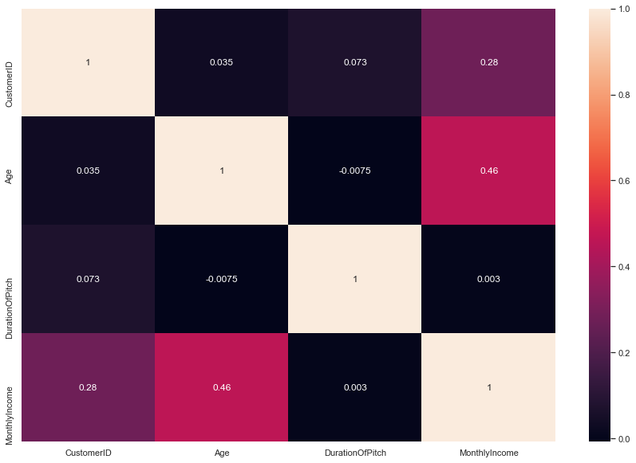

```python
plt.figure(figsize=(15,10))
sns.heatmap(df.corr(),annot=True)
plt.show()
```

### Observation

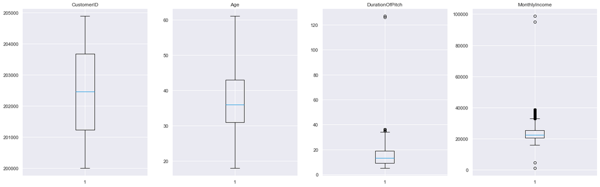

```python
# outlier detection using boxplot
numerical_col = df.select_dtypes(include=np.number).columns.tolist()
plt.figure(figsize=(20,30))

for i, variable in enumerate(numerical_col):
                     plt.subplot(5,4,i+1)
                     plt.boxplot(df[variable],whis=1.5)
                     plt.tight_layout()
                     plt.title(variable)

plt.show()
```

```python
def treat_outliers(df,col):
    '''
    treats outliers in a varaible
    col: str, name of the numerical varaible
    df: data frame
    col: name of the column
    '''
    Q1=df[col].quantile(0.25) # 25th quantile
    Q3=df[col].quantile(0.75)  # 75th quantile
    IQR=Q3-Q1
    Lower_Whisker = Q1 - 1.5*IQR
    Upper_Whisker = Q3 + 1.5*IQR
    df[col] = np.clip(df[col], Lower_Whisker, Upper_Whisker) # all the values samller than Lower_Whisker will be assigned value of Lower_whisker
                                                            # and all the values above upper_whishker will be assigned value of upper_Whisker
    return df

def treat_outliers_all(df, col_list):
    '''
    treat outlier in all numerical varaibles
    col_list: list of numerical varaibles
    df: data frame
    '''
    for c in col_list:
        df = treat_outliers(df,c)

    return df
```

```python
df=df.drop(['CustomerID'],axis=1)
```

## Split Data

```python
# Creating dummies
dummy_df = pd.get_dummies(df, columns=['TypeofContact','Occupation','Gender','ProductPitched','MaritalStatus','Designation','CityTier', 'NumberOfPersonVisiting', 'NumberOfFollowups', 'PreferredPropertyStar', 'NumberOfTrips', 'Passport', 'PitchSatisfactionScore', 'OwnCar', 'NumberOfChildrenVisiting'],drop_first=True)
dummy_df.head()
```

|  | ProdTaken | Age | DurationOfPitch | MonthlyIncome | TypeofContact_Self Enquiry | Occupation_Large Business | Occupation_Salaried | Occupation_Small Business | Gender_Male | ProductPitched_Deluxe | ... | NumberOfTrips_22.0 | Passport_1 | PitchSatisfactionScore_2 | PitchSatisfactionScore_3 | PitchSatisfactionScore_4 | PitchSatisfactionScore_5 | OwnCar_1 | NumberOfChildrenVisiting_1.0 | NumberOfChildrenVisiting_2.0 | NumberOfChildrenVisiting_3.0 |
| --- | --- | --- | --- | --- | --- | --- | --- | --- | --- | --- | --- | --- | --- | --- | --- | --- | --- | --- | --- | --- | --- |
| 0 | 1 | 41.0 | 6.0 | 20993.0 | 1 | 0 | 1 | 0 | 0 | 1 | ... | 0 | 1 | 1 | 0 | 0 | 0 | 1 | 0 | 0 | 0 |
| 1 | 0 | 49.0 | 14.0 | 20130.0 | 0 | 0 | 1 | 0 | 1 | 1 | ... | 0 | 0 | 0 | 1 | 0 | 0 | 1 | 0 | 1 | 0 |
| 2 | 1 | 37.0 | 8.0 | 17090.0 | 1 | 0 | 0 | 0 | 1 | 0 | ... | 0 | 1 | 0 | 1 | 0 | 0 | 0 | 0 | 0 | 0 |
| 3 | 0 | 33.0 | 9.0 | 17909.0 | 0 | 0 | 1 | 0 | 0 | 0 | ... | 0 | 1 | 0 | 0 | 0 | 1 | 1 | 1 | 0 | 0 |
| 4 | 0 | 36.0 | 8.0 | 18468.0 | 1 | 0 | 0 | 1 | 1 | 0 | ... | 0 | 0 | 0 | 0 | 0 | 1 | 1 | 0 | 0 | 0 |

5 rows × 53 columns

```python
column_names = list(dummy_df.columns)
column_names.remove('ProdTaken')                     # Keep only names of features by removing the name of target variable
feature_names = column_names
print(feature_names)
```

```
['Age', 'DurationOfPitch', 'MonthlyIncome', 'TypeofContact_Self Enquiry', 'Occupation_Large Business', 'Occupation_Salaried', 'Occupation_Small Business', 'Gender_Male', 'ProductPitched_Deluxe', 'ProductPitched_King', 'ProductPitched_Standard', 'ProductPitched_Super Deluxe', 'MaritalStatus_Married',…
```

```python
X = dummy_df.drop(['ProdTaken'],axis=1)
y = dummy_df['ProdTaken'].astype('int64')
```

```python
# Splitting data into training and test set:
X_train, X_test, y_train, y_test =train_test_split(X, y, test_size=0.3, random_state=1,stratify=y)
print(X_train.shape, X_test.shape)
```

```
(3404, 52) (1459, 52)
```

```python
y.value_counts(1)
```

```
0    0.811433
1    0.188567
Name: ProdTaken, dtype: float64
```

```python
y_test.value_counts(1)
```

```
0    0.811515
1    0.188485
Name: ProdTaken, dtype: float64
```

## Model can make wrong predictions as:

1. Predicting a customers will purchase the wellness travel package when they would not purchase the wellness package.
2. Predicting a customers would not purchase the wellness package while they will purchase the wellness package.

## Which case is more important?

1. If the model predicts customers will not purchase the wellness travel package then the company would incur loss for the company and resources used.
2. If the model predicts customers will purchase the wellness product and they do not it will be loss on the company and resources.

## Which metric to optimize?

We would want Precision Score to be maximized true positive as marketing resources are limited, the greater the Precision Score higher the chances of predicting the True Positive of customers who will purchase the new travel package.

```python
##  Function to calculate different metric scores of the model - Accuracy, Recall and Precision
def get_metrics_score(model,flag=True):
    '''
    model : classifier to predict values of X

    '''
    # defining an empty list to store train and test results
    score_list=[]

    pred_train = model.predict(X_train)
    pred_test = model.predict(X_test)

    train_acc = model.score(X_train,y_train)
    test_acc = model.score(X_test,y_test)

    train_recall = metrics.recall_score(y_train,pred_train)
    test_recall = metrics.recall_score(y_test,pred_test)

    train_precision = metrics.precision_score(y_train,pred_train)
    test_precision = metrics.precision_score(y_test,pred_test)

    train_f1 = f1_score(y_train,pred_train)
    test_f1 = f1_score(y_test,pred_test)

    score_list.extend((train_acc,test_acc,train_recall,test_recall,train_precision,test_precision, train_f1, test_f1))

    # If the flag is set to True then only the following print statements will be dispayed. The default value is set to True.
    if flag == True:
        print("Accuracy on training set : ",model.score(X_train,y_train))
        print("Accuracy on test set : ",model.score(X_test,y_test))
        print("Recall on training set : ",metrics.recall_score(y_train,pred_train))
        print("Recall on test set : ",metrics.recall_score(y_test,pred_test))
        print("Precision on training set : ",metrics.precision_score(y_train,pred_train))
        print("Precision on test set : ",metrics.precision_score(y_test,pred_test))
        print("F1-Score on training set : ",metrics.f1_score(y_train,pred_train))
        print("F1-Score on test set : ",metrics.f1_score(y_test,pred_test))

    return score_list # returning the list with train and test scores
```

```python
def make_confusion_matrix(model,y_actual,labels=[1, 0]):
    '''
    model : classifier to predict values of X
    y_actual : ground truth

    '''
    y_predict = model.predict(X_test)
    cm=metrics.confusion_matrix( y_actual, y_predict, labels=[0, 1])
    df_cm = pd.DataFrame(cm, index = [i for i in ["Actual - No","Actual - Yes"]],
                  columns = [i for i in ['Predicted - No','Predicted - Yes']])
    group_counts = ["{0:0.0f}".format(value) for value in
                cm.flatten()]
    group_percentages = ["{0:.2%}".format(value) for value in
                         cm.flatten()/np.sum(cm)]
    labels = [f"{v1}\n{v2}" for v1, v2 in
              zip(group_counts,group_percentages)]
    labels = np.asarray(labels).reshape(2,2)
    plt.figure(figsize = (10,7))
    sns.heatmap(df_cm, annot=labels,fmt='')
    plt.ylabel('True label')
    plt.xlabel('Predicted label')
```

## Confusion Matrix -

1. Customer will Purchase and the model predicted it correctly that customer purchased the new product : True Positive (observed=1,predicted=1)
1. Customer didn't Purchase and the model predicted that customer purchased the new product : False Positive (observed=0,predicted=1)
1. Customere didn't Purchase and the model predicted Customer didn't Purchased the new product: True Negative (observed=0,predicted=0)
1. Customer will Purchase and the model predicted Customer didn't Purchased the new product: False Negative (observed=1,predicted=0)

```python
#Fitting the model
dtree = DecisionTreeClassifier(criterion='gini',class_weight={0:0.19,1:0.81},random_state=1)
```

```python
dtree.fit(X_train, y_train)
```

```
DecisionTreeClassifier(class_weight={0: 0.19, 1: 0.81}, random_state=1)
```

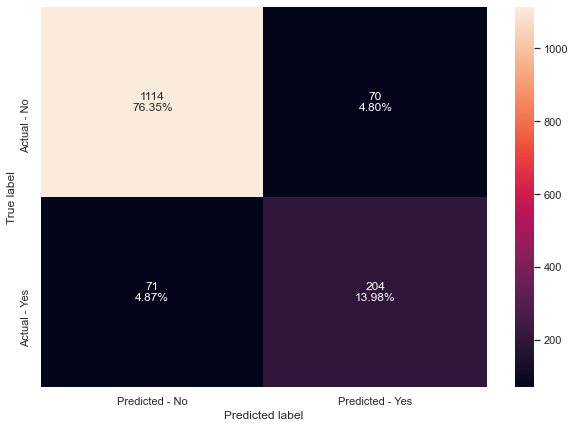

```python
#Creating confusion matrix
make_confusion_matrix(dtree,y_test)
```

```python
#Calculating different metrics
get_metrics_score(dtree)
```

```
Accuracy on training set :  1.0
Accuracy on test set :  0.9033584647018505
Recall on training set :  1.0
Recall on test set :  0.7418181818181818
Precision on training set :  1.0
Precision on test set :  0.7445255474452555
F1-Score on training set :  1.0
F1-Score on test set :  0.7431693989071038
```

```
[1.0,
 0.9033584647018505,
 1.0,
 0.7418181818181818,
 1.0,
 0.7445255474452555,
 1.0,
 0.7431693989071038]
```

### Observation

1. Decision tree is overfitting the training data.
2. Let's try bagging classifier and see if the model performance improves.

## Bagging Classifier

```python
bagging = BaggingClassifier(random_state=1)
bagging.fit(X_train,y_train)
```

```
BaggingClassifier(random_state=1)
```

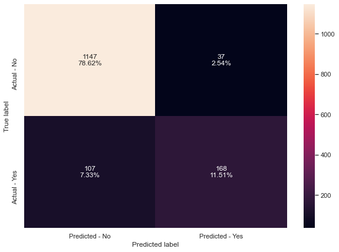

```python
make_confusion_matrix(bagging,y_test)
```

```python
#Calculating different metrics
get_metrics_score(bagging)
```

```
Accuracy on training set :  0.9929494712103408
Accuracy on test set :  0.9013022618231665
Recall on training set :  0.9626168224299065
Recall on test set :  0.610909090909091
Precision on training set :  1.0
Precision on test set :  0.8195121951219512
F1-Score on training set :  0.9809523809523809
F1-Score on test set :  0.7000000000000001
```

```
[0.9929494712103408,
 0.9013022618231665,
 0.9626168224299065,
 0.610909090909091,
 1.0,
 0.8195121951219512,
 0.9809523809523809,
 0.7000000000000001]
```

## Bagging Classifier with weighted decision tree

```python
bagging_wt = BaggingClassifier(base_estimator=DecisionTreeClassifier(criterion='gini',class_weight={0:0.19,1:0.81},random_state=1),random_state=1)
bagging_wt.fit(X_train,y_train)
```

```
BaggingClassifier(base_estimator=DecisionTreeClassifier(class_weight={0: 0.19,
                                                                      1: 0.81},
                                                        random_state=1),
                  random_state=1)
```

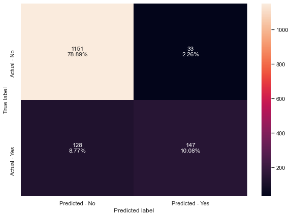

```python
make_confusion_matrix(bagging_wt,y_test)
```

```python
get_metrics_score(bagging_wt)
```

```
Accuracy on training set :  0.9917743830787309
Accuracy on test set :  0.8896504455106237
Recall on training set :  0.956386292834891
Recall on test set :  0.5345454545454545
Precision on training set :  1.0
Precision on test set :  0.8166666666666667
F1-Score on training set :  0.9777070063694268
F1-Score on test set :  0.6461538461538462
```

```
[0.9917743830787309,
 0.8896504455106237,
 0.956386292834891,
 0.5345454545454545,
 1.0,
 0.8166666666666667,
 0.9777070063694268,
 0.6461538461538462]
```

## Random Forest

```python
rf = RandomForestClassifier(random_state=1)
rf.fit(X_train,y_train)
```

```
RandomForestClassifier(random_state=1)
```

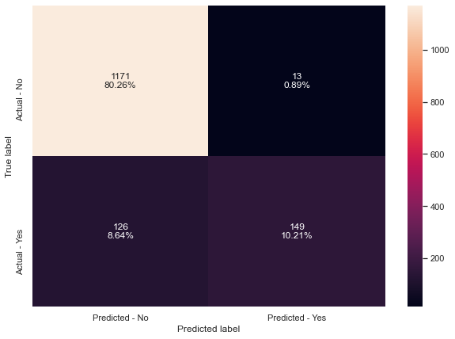

```python
make_confusion_matrix(rf,y_test)
```

```python
get_metrics_score(rf)
```

```
Accuracy on training set :  1.0
Accuracy on test set :  0.9047292666209733
Recall on training set :  1.0
Recall on test set :  0.5418181818181819
Precision on training set :  1.0
Precision on test set :  0.9197530864197531
F1-Score on training set :  1.0
F1-Score on test set :  0.6819221967963387
```

```
[1.0,
 0.9047292666209733,
 1.0,
 0.5418181818181819,
 1.0,
 0.9197530864197531,
 1.0,
 0.6819221967963387]
```

### Observation

1. Accuracy and precision are slightly overfitting the training data.
2. Recall and F1 is overfitting but there has being an improvement on the traing data but a decline on the test set from the previous decision tree
3. Random Forest with weight has performed well in terms of accuracy and precision, but it is not able to generalize well on the test data in terms of recall.

## Random forest with class weights

```python
rf_wt = RandomForestClassifier(class_weight={0:0.19,1:0.81}, random_state=1)
rf_wt.fit(X_train,y_train)
```

```
RandomForestClassifier(class_weight={0: 0.19, 1: 0.81}, random_state=1)
```

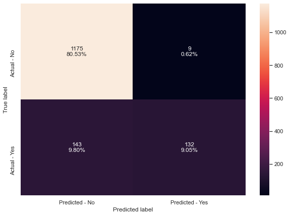

```python
make_confusion_matrix(rf_wt,y_test)
```

```python
get_metrics_score(rf_wt)
```

```
Accuracy on training set :  1.0
Accuracy on test set :  0.8958190541466758
Recall on training set :  1.0
Recall on test set :  0.48
Precision on training set :  1.0
Precision on test set :  0.9361702127659575
F1-Score on training set :  1.0
F1-Score on test set :  0.6346153846153846
```

```
[1.0,
 0.8958190541466758,
 1.0,
 0.48,
 1.0,
 0.9361702127659575,
 1.0,
 0.6346153846153846]
```

## Observation

1. Random Forest with weight has performed well in terms of accuracy and precision, but it is not able to generalize well on the test data in terms of recall.
2. Recall and f1 didnt improve from the previous input

## Using GridSearch for Hyperparameter tuning model

### Tuning Decision Tree

```python
from sklearn.model_selection import GridSearchCV
```

```python
# Choose the type of classifier.
dtree_estimator = DecisionTreeClassifier(class_weight={0:0.19,1:0.81},random_state=1)

# Grid of parameters to choose from
parameters = {'max_depth': np.arange(2,30),
              'min_samples_leaf': [1, 2, 5, 7, 10],
              'max_leaf_nodes' : [2, 3, 5, 10,15],
              'min_impurity_decrease': [0.0001,0.001,0.01,0.1]
             }

# Type of scoring used to compare parameter combinations
scorer = metrics.make_scorer(metrics.precision_score)

# Run the grid search
grid_obj = GridSearchCV(dtree_estimator, parameters, scoring=scorer)
grid_obj = grid_obj.fit(X_train, y_train)

# Set the clf to the best combination of parameters
dtree_estimator = grid_obj.best_estimator_

# Fit the best algorithm to the data.
dtree_estimator.fit(X_train, y_train)
```

```
DecisionTreeClassifier(class_weight={0: 0.19, 1: 0.81}, max_depth=7,
                       max_leaf_nodes=10, min_impurity_decrease=0.0001,
                       random_state=1)
```

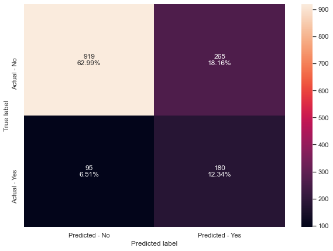

```python
make_confusion_matrix(dtree_estimator,y_test)
```

```python
get_metrics_score(dtree_estimator)
```

```
Accuracy on training set :  0.7596944770857814
Accuracy on test set :  0.7532556545579164
Recall on training set :  0.6651090342679128
Recall on test set :  0.6545454545454545
Precision on training set :  0.4145631067961165
Precision on test set :  0.4044943820224719
F1-Score on training set :  0.5107655502392344
F1-Score on test set :  0.5
```

```
[0.7596944770857814,
 0.7532556545579164,
 0.6651090342679128,
 0.6545454545454545,
 0.4145631067961165,
 0.4044943820224719,
 0.5107655502392344,
 0.5]
```

### Tuning Bagging Classifier

```python
# grid search for bagging classifier
cl1 = DecisionTreeClassifier(class_weight={0:0.19,1:0.81},random_state=1)
param_grid = {'base_estimator':[cl1],
              'n_estimators':[5,7,15,51,101],
              'max_features': [0.7,0.8,0.9,1]
             }

grid = GridSearchCV(BaggingClassifier(random_state=1,bootstrap=True), param_grid=param_grid, scoring = 'precision', cv = 5)
grid.fit(X_train, y_train)
```

```
GridSearchCV(cv=5, estimator=BaggingClassifier(random_state=1),
             param_grid={'base_estimator': [DecisionTreeClassifier(class_weight={0: 0.19,
                                                                                 1: 0.81},
                                                                   random_state=1)],
                         'max_features': [0.7, 0.8, 0.9, 1],
                         'n_estimators': [5, 7, 15, 51, 101]},
             scoring='precision')
```

```python
## getting the best estimator
bagging_estimator  = grid.best_estimator_
bagging_estimator.fit(X_train,y_train)
```

```
BaggingClassifier(base_estimator=DecisionTreeClassifier(class_weight={0: 0.19,
                                                                      1: 0.81},
                                                        random_state=1),
                  max_features=0.7, n_estimators=101, random_state=1)
```

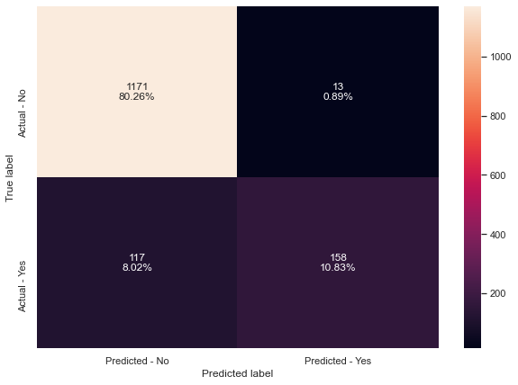

```python
make_confusion_matrix(bagging_estimator,y_test)
```

```python
get_metrics_score(bagging_estimator)
```

```
Accuracy on training set :  1.0
Accuracy on test set :  0.9108978752570254
Recall on training set :  1.0
Recall on test set :  0.5745454545454546
Precision on training set :  1.0
Precision on test set :  0.9239766081871345
F1-Score on training set :  1.0
F1-Score on test set :  0.7085201793721974
```

```
[1.0,
 0.9108978752570254,
 1.0,
 0.5745454545454546,
 1.0,
 0.9239766081871345,
 1.0,
 0.7085201793721974]
```

### Observation

1. There is a slight Overfitting in decision tree accuracy and precision
2. Overfitting in decision tree on F1 and recall is high
3. General prediction output has improved from pevious model

## Tuning Random Forest

```python
# Choose the type of classifier.
rf_estimator = RandomForestClassifier(random_state=1)

# Grid of parameters to choose from
parameters = {
        "n_estimators": [110,251,501],
        "min_samples_leaf": np.arange(1, 6,1),
        "max_features": [0.7,0.9,'log2','auto'],
        "max_samples": [0.7,0.9,None],
}


# Run the grid search
grid_obj = GridSearchCV(rf_estimator, parameters, scoring=scorer,cv=5)
grid_obj = grid_obj.fit(X_train, y_train)

# Set the clf to the best combination of parameters
rf_estimator = grid_obj.best_estimator_

# Fit the best algorithm to the data.
rf_estimator.fit(X_train, y_train)
```

```
RandomForestClassifier(max_features='log2', max_samples=0.9, n_estimators=501,
                       random_state=1)
```

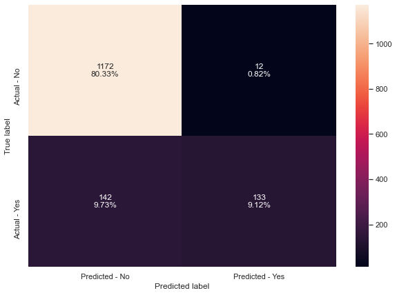

```python
make_confusion_matrix(rf_estimator,y_test)
```

```python
get_metrics_score(rf_estimator)
```

```
Accuracy on training set :  1.0
Accuracy on test set :  0.8944482522275531
Recall on training set :  1.0
Recall on test set :  0.48363636363636364
Precision on training set :  1.0
Precision on test set :  0.9172413793103448
F1-Score on training set :  1.0
F1-Score on test set :  0.6333333333333333
```

```
[1.0,
 0.8944482522275531,
 1.0,
 0.48363636363636364,
 1.0,
 0.9172413793103448,
 1.0,
 0.6333333333333333]
```

### Observation

1. Precision has still maintained a similar range in the test and training set
2. There is a decline in the test data of Accuracy, Recall and F1

## Comparing all the models

```python
feature_names = X_train.columns
```

```python
# importance of features in the tree building ( The importance of a feature is computed as the
#(normalized) total reduction of the criterion brought by that feature. It is also known as the Gini importance )

print (pd.DataFrame(rf.feature_importances_, columns = ["Imp"], index = X_train.columns).sort_values(by = 'Imp', ascending = False))
```

```
                                   Imp
MonthlyIncome                 0.121372
Age                           0.111406
DurationOfPitch               0.093888
Passport_1                    0.072580
CityTier_3                    0.027056
Designation_Executive         0.026016
MaritalStatus_Single          0.025918
PreferredPropertyStar_5.0     0.024292
TypeofContact_Self Enquiry    0.023745
Gender_Male                   0.022515
OwnCar_1                      0.021703
PitchSatisfactionScore_4      0.018797
NumberOfTrips_2.0             0.018669
Occupation_Salaried           0.018607
PitchSatisfactionScore_3      0.018575
PitchSatisfactionScore_5      0.018513
Occupation_Small Business     0.017321
PreferredPropertyStar_4.0     0.017294
NumberOfChildrenVisiting_1.0  0.016631
NumberOfFollowups_4.0         0.016502
MaritalStatus_Married         0.016110
NumberOfFollowups_5.0         0.016008
NumberOfPersonVisiting_3      0.015868
NumberOfTrips_3.0             0.015431
NumberOfFollowups_3.0         0.015238
MaritalStatus_Unmarried       0.014797
NumberOfPersonVisiting_2      0.013705
Occupation_Large Business     0.013249
NumberOfChildrenVisiting_2.0  0.012619
NumberOfPersonVisiting_4      0.012024
NumberOfTrips_6.0             0.010015
Designation_Manager           0.009930
NumberOfTrips_7.0             0.009846
PitchSatisfactionScore_2      0.009700
NumberOfFollowups_6.0         0.009474
ProductPitched_Deluxe         0.009333
NumberOfTrips_4.0             0.009006
CityTier_2                    0.008673
NumberOfTrips_5.0             0.008382
ProductPitched_Standard       0.007525
Designation_Senior Manager    0.006866
NumberOfChildrenVisiting_3.0  0.006427
ProductPitched_Super Deluxe   0.004950
NumberOfFollowups_2.0         0.004610
NumberOfTrips_8.0             0.004291
Designation_VP                0.002167
ProductPitched_King           0.002093
NumberOfTrips_20.0            0.000227
NumberOfPersonVisiting_5      0.000036
NumberOfTrips_22.0            0.000000
NumberOfTrips_21.0            0.000000
NumberOfTrips_19.0            0.000000
```

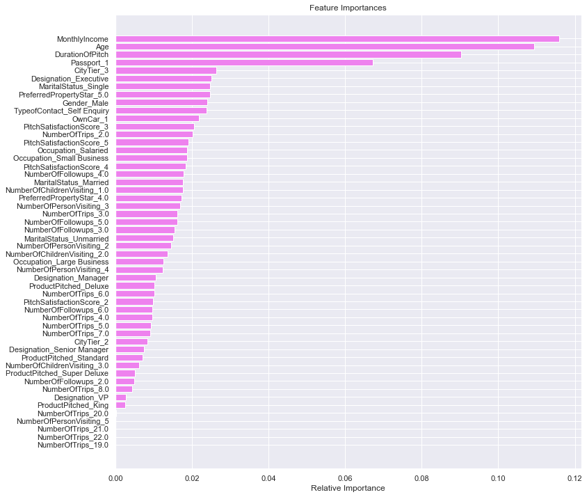

```python
importances = rf_estimator.feature_importances_
indices = np.argsort(importances)

plt.figure(figsize=(12,12))
plt.title('Feature Importances')
plt.barh(range(len(indices)), importances[indices], color='violet', align='center')
plt.yticks(range(len(indices)), [feature_names[i] for i in indices])
plt.xlabel('Relative Importance')
plt.show()
```

### Observation

1. Monthly Income is the most important variable followed by Age, duration of pitch and customers who own passport.

```python
# defining list of models
models = [dtree,bagging,bagging_wt,rf,rf_wt,dtree_estimator,bagging_estimator,rf_estimator]

# defining empty lists to add train and test results
acc_train = []
acc_test = []
recall_train = []
recall_test = []
precision_train = []
precision_test = []
f1_train = []
f1_test = []

# looping through all the models to get the accuracy,recall and precision scores
for model in models:
    # accuracy score
    j = get_metrics_score(model,False)
    acc_train.append(np.round(j[0],2))
    acc_test.append(np.round(j[1],2))
    recall_train.append(np.round(j[2],2))
    recall_test.append(np.round(j[3],2))
    precision_train.append(np.round(j[4],2))
    precision_test.append(np.round(j[5],2))
    f1_train.append(np.round(j[6],2))
    f1_test.append(np.round(j[7],2))
```

```python
comparison_frame = pd.DataFrame({'Model':['Decision Tree','Tuned Decision Tree','Bagging Classifier',
                                          'Weighted Bagging Classifier','Tuned Bagging Classifier',
                                          'Random Forest','Weighted Random Forest','Tuned Random Forest'],
                                          'Train_Accuracy': acc_train,
                                          'Test_Accuracy': acc_test,
                                          'Train_Recall': recall_train,
                                          'Test_Recall': recall_test,
                                          'Train_Precision': precision_train,
                                          'Test_Precision': precision_test,
                                          'Train_F1': f1_train,
                                          'Test_F1': f1_test})
comparison_frame
```

[output not shown]

## OBSERVATION:

# Model building - Boosting

```python
## Function to create confusion matrix
def make_confusion_matrix(model,y_actual,labels=[1, 0]):
    '''
    model : classifier to predict values of X
    y_actual : ground truth

    '''
    y_predict = model.predict(X_test)
    cm=metrics.confusion_matrix( y_actual, y_predict, labels=[0, 1])
    df_cm = pd.DataFrame(cm, index = [i for i in ["Actual - No","Actual - Yes"]],
                  columns = [i for i in ['Predicted - No','Predicted - Yes']])
    group_counts = ["{0:0.0f}".format(value) for value in
                cm.flatten()]
    group_percentages = ["{0:.2%}".format(value) for value in
                         cm.flatten()/np.sum(cm)]
    labels = [f"{v1}\n{v2}" for v1, v2 in
              zip(group_counts,group_percentages)]
    labels = np.asarray(labels).reshape(2,2)
    plt.figure(figsize = (10,7))
    sns.heatmap(df_cm, annot=labels,fmt='')
    plt.ylabel('True label')
    plt.xlabel('Predicted label')
```

```python
abc = AdaBoostClassifier(random_state=1)
abc.fit(X_train,y_train)
```

```
AdaBoostClassifier(random_state=1)
```

```python
#Using above defined function to get accuracy, recall and precision on train and test set
abc_score=get_metrics_score(abc)
```

```
Accuracy on training set :  0.8516451233842538
Accuracy on test set :  0.8540095956134338
Recall on training set :  0.3395638629283489
Recall on test set :  0.3781818181818182
Precision on training set :  0.7290969899665551
Precision on test set :  0.7123287671232876
F1-Score on training set :  0.463336875664187
F1-Score on test set :  0.49406175771971494
```

### Observation.

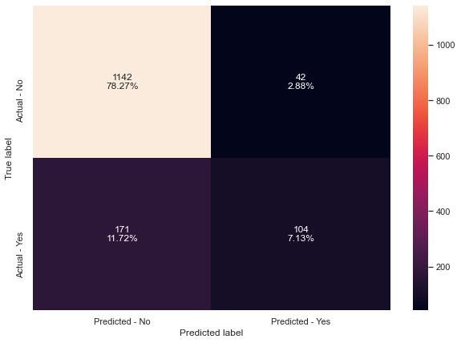

```python
make_confusion_matrix(abc,y_test)
```

```python
gbc = GradientBoostingClassifier(random_state=1)
gbc.fit(X_train,y_train)
```

```
GradientBoostingClassifier(random_state=1)
```

```python
#Using above defined function to get accuracy, recall and precision on train and test set
gbc_score=get_metrics_score(gbc)
```

```
Accuracy on training set :  0.886310223266745
Accuracy on test set :  0.8711446196024675
Recall on training set :  0.46105919003115264
Recall on test set :  0.4109090909090909
Precision on training set :  0.8783382789317508
Precision on test set :  0.8129496402877698
F1-Score on training set :  0.6046986721144025
F1-Score on test set :  0.5458937198067633
```

### Observation

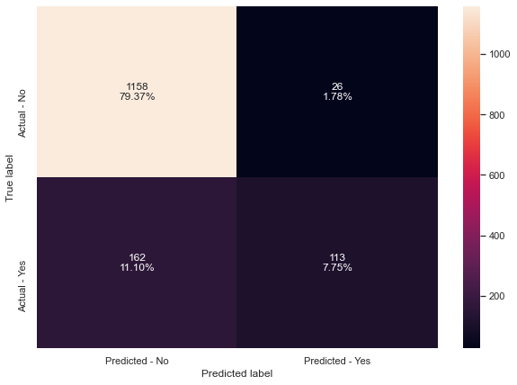

```python
make_confusion_matrix(gbc,y_test)
```

### Observation

1. There is a slight improvement in the true positive from 104(7.13%) and 113(7.75%)

## XGBoost Classifier

```python
xgb = XGBClassifier(random_state=1)
xgb.fit(X_train,y_train)
```

[output not shown]

```
XGBClassifier(base_score=0.5, booster='gbtree', colsample_bylevel=1,
              colsample_bynode=1, colsample_bytree=1, gamma=0, gpu_id=-1,
              importance_type='gain', interaction_constraints='',
              learning_rate=0.300000012, max_delta_step=0, max_depth=6,
              min_child_weight=1, missing=nan, monotone_constraints='()',
              n_estimators=100, n_jobs=4, num_parallel_tree=1, random_state=1,
              reg_alpha=0, reg_lambda=1, scale_pos_weight=1, subsample=1,
              tree_method='exact', validate_parameters=1, verbosity=None)
```

```python
#Using above defined function to get accuracy, recall and precision on train and test set
xgb_score=get_metrics_score(xgb)
```

```
Accuracy on training set :  0.9997062279670975
Accuracy on test set :  0.9307745030843043
Recall on training set :  0.9984423676012462
Recall on test set :  0.7381818181818182
Precision on training set :  1.0
Precision on test set :  0.875
F1-Score on training set :  0.9992205767731879
F1-Score on test set :  0.8007889546351084
```

### Observation

1. There is a heavy overfitting in the recall, precision and F1 score which will be treated in the next hyperparameter tuning
2. Accuracy seem to be slightly overfitting

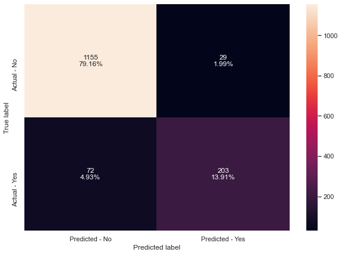

```python
make_confusion_matrix(xgb,y_test)
```

## Hyperparameter Tuning

```python
# Choose the type of classifier.
abc_tuned = AdaBoostClassifier(random_state=1)

# Grid of parameters to choose from
## add from article
parameters = {
    #Let's try different max_depth for base_estimator
    "base_estimator":[DecisionTreeClassifier(max_depth=1),DecisionTreeClassifier(max_depth=2),DecisionTreeClassifier(max_depth=3)],
    "n_estimators": np.arange(10,110,10),
    "learning_rate":np.arange(0.1,2,0.1)
}

# Type of scoring used to compare parameter combinations
acc_scorer = metrics.make_scorer(metrics.precision_score)

# Run the grid search
grid_obj = GridSearchCV(abc_tuned, parameters, scoring=acc_scorer,cv=5)
grid_obj = grid_obj.fit(X_train, y_train)

# Set the clf to the best combination of parameters
abc_tuned = grid_obj.best_estimator_

# Fit the best algorithm to the data.
abc_tuned.fit(X_train, y_train)
```

```
AdaBoostClassifier(base_estimator=DecisionTreeClassifier(max_depth=1),
                   learning_rate=0.1, n_estimators=40, random_state=1)
```

```python
#Using above defined function to get accuracy, recall and precision on train and test set
abc_tuned_score=get_metrics_score(abc_tuned)
```

```
Accuracy on training set :  0.8172737955346651
Accuracy on test set :  0.820424948594928
Recall on training set :  0.03426791277258567
Recall on test set :  0.05090909090909091
Precision on training set :  0.9166666666666666
Precision on test set :  0.9333333333333333
F1-Score on training set :  0.06606606606606606
F1-Score on test set :  0.09655172413793103
```

### Observation

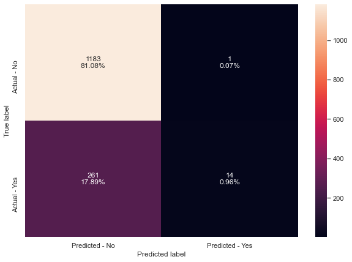

```python
make_confusion_matrix(abc_tuned,y_test)
```

### OBSERVATION

1. The true positive has declined from the previous train data

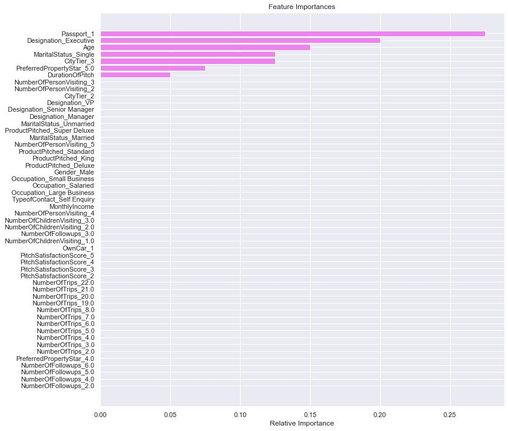

```python
importances = abc_tuned.feature_importances_
indices = np.argsort(importances)
feature_names = list(X.columns)

plt.figure(figsize=(12,12))
plt.title('Feature Importances')
plt.barh(range(len(indices)), importances[indices], color='violet', align='center')
plt.yticks(range(len(indices)), [feature_names[i] for i in indices])
plt.xlabel('Relative Importance')
plt.show()
```

### Observation.

1. The most important variable is the customers who have passport.
2. Other important variable are customers who are executives, Age and Single

## Gradient Boosting Classifier

```python
gbc_init = GradientBoostingClassifier(init=AdaBoostClassifier(random_state=1),random_state=1)
gbc_init.fit(X_train,y_train)
```

```
GradientBoostingClassifier(init=AdaBoostClassifier(random_state=1),
                           random_state=1)
```

```python
#Using above defined function to get accuracy, recall and precision on train and test set
gbc_init_score=get_metrics_score(gbc_init)
```

```
Accuracy on training set :  0.8854289071680376
Accuracy on test set :  0.8732008224811515
Recall on training set :  0.4485981308411215
Recall on test set :  0.41454545454545455
Precision on training set :  0.8888888888888888
Precision on test set :  0.8260869565217391
F1-Score on training set :  0.5962732919254659
F1-Score on test set :  0.5520581113801453
```

### Observation

1. There is slight overfitting on all metric scores.
2. The Metric score improved from previous model

```python
# Choose the type of classifier.
gbc_tuned = GradientBoostingClassifier(init=AdaBoostClassifier(random_state=1),random_state=1)

# Grid of parameters to choose from
## add from article
parameters = {
    "n_estimators": [100,150,200,250],
    "subsample":[0.8,0.9,1],
    "max_features":[0.7,0.8,0.9,1]
}

# Type of scoring used to compare parameter combinations
acc_scorer = metrics.make_scorer(metrics.precision_score)

# Run the grid search
grid_obj = GridSearchCV(gbc_tuned, parameters, scoring=acc_scorer,cv=5)
grid_obj = grid_obj.fit(X_train, y_train)

# Set the clf to the best combination of parameters
gbc_tuned = grid_obj.best_estimator_

# Fit the best algorithm to the data.
gbc_tuned.fit(X_train, y_train)
```

```
GradientBoostingClassifier(init=AdaBoostClassifier(random_state=1),
                           max_features=1, random_state=1, subsample=1)
```

```python
#Using above defined function to get accuracy, recall and precision on train and test set
gbc_tuned_score=get_metrics_score(gbc_tuned)
```

```
Accuracy on training set :  0.8393066980023501
Accuracy on test set :  0.8361891706648389
Recall on training set :  0.16666666666666666
Recall on test set :  0.1709090909090909
Precision on training set :  0.8991596638655462
Precision on test set :  0.8103448275862069
F1-Score on training set :  0.2812089356110381
F1-Score on test set :  0.2822822822822823
```

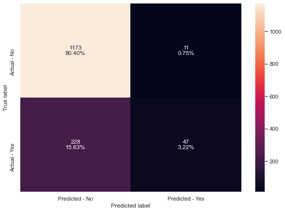

```python
make_confusion_matrix(gbc_tuned,y_test)
```

### Observation.

1. True Positive is low compared to the bagging prediction model

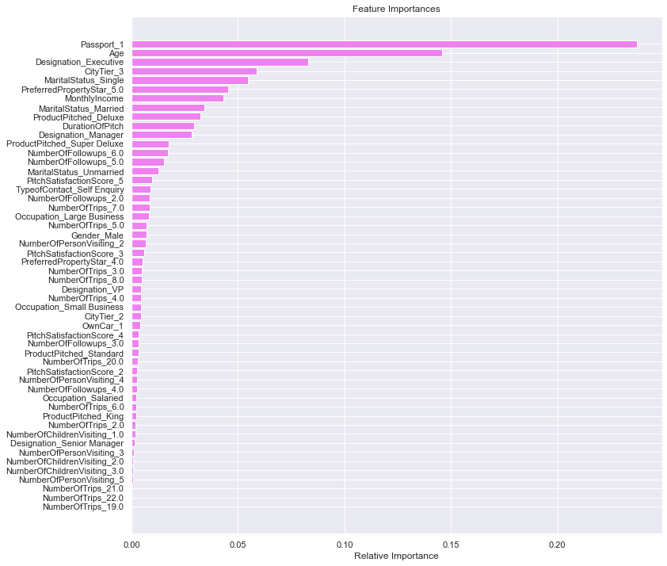

```python
importances = gbc_tuned.feature_importances_
indices = np.argsort(importances)
feature_names = list(X.columns)

plt.figure(figsize=(12,12))
plt.title('Feature Importances')
plt.barh(range(len(indices)), importances[indices], color='violet', align='center')
plt.yticks(range(len(indices)), [feature_names[i] for i in indices])
plt.xlabel('Relative Importance')
plt.show()
```

### Observation

1. Customers who own passport, Age and Executive are the most important variables to look out for

## XGBoost Classifier

```python
# Choose the type of classifier.
xgb_tuned = XGBClassifier(random_state=1, eval_metric='logloss')

# Grid of parameters to choose from
parameters = {
    "n_estimators": [10,30,50],
    "scale_pos_weight":[1,2,5],
    "subsample":[0.7,0.9,1],
    "learning_rate":[0.05, 0.1,0.2],
    "colsample_bytree":[0.7,0.9,1],
    "colsample_bylevel":[0.5,0.7,1]
}

# Type of scoring used to compare parameter combinations
scorer = metrics.make_scorer(metrics.precision_score)

# Run the grid search
grid_obj = GridSearchCV(xgb_tuned, parameters,scoring=scorer,cv=5)
grid_obj = grid_obj.fit(X_train, y_train)

# Set the clf to the best combination of parameters
xgb_tuned = grid_obj.best_estimator_

# Fit the best algorithm to the data.
xgb_tuned.fit(X_train, y_train)
```

```
XGBClassifier(base_score=0.5, booster='gbtree', colsample_bylevel=1,
              colsample_bynode=1, colsample_bytree=1, eval_metric='logloss',
              gamma=0, gpu_id=-1, importance_type='gain',
              interaction_constraints='', learning_rate=0.2, max_delta_step=0,
              max_depth=6, min_child_weight=1, missing=nan,
              monotone_constraints='()', n_estimators=50, n_jobs=4,
              num_parallel_tree=1, random_state=1, reg_alpha=0, reg_lambda=1,
              scale_pos_weight=1, subsample=0.9, tree_method='exact',
              validate_parameters=1, verbosity=None)
```

```python
#Using above defined function to get accuracy, recall and precision on train and test set
xgb_tuned_score=get_metrics_score(xgb_tuned)
```

```
Accuracy on training set :  0.9744418331374853
Accuracy on test set :  0.9067854694996573
Recall on training set :  0.867601246105919
Recall on test set :  0.6072727272727273
Precision on training set :  0.9964221824686941
Precision on test set :  0.8564102564102564
F1-Score on training set :  0.9275603663613655
F1-Score on test set :  0.7106382978723405
```

### Observation

1. There is alot of overfitting in the xgb tuned score.

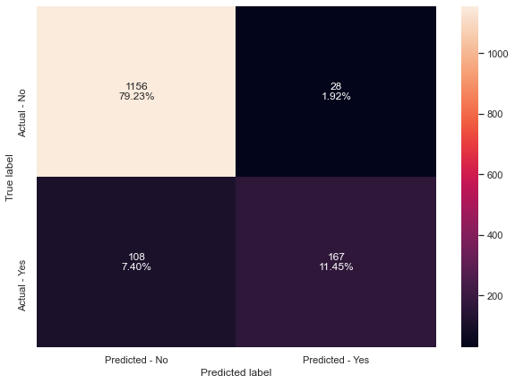

```python
make_confusion_matrix(xgb_tuned,y_test)
```

### Observation

1. There an improvemrnt in the True Posistive form previous output

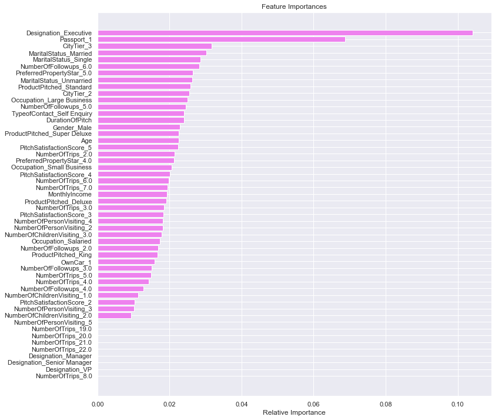

```python
importances = xgb_tuned.feature_importances_
indices = np.argsort(importances)
feature_names = list(X.columns)

plt.figure(figsize=(12,12))
plt.title('Feature Importances')
plt.barh(range(len(indices)), importances[indices], color='violet', align='center')
plt.yticks(range(len(indices)), [feature_names[i] for i in indices])
plt.xlabel('Relative Importance')
plt.show()
```

### Observation

Executive, passport and city tier 3 are the most important variable

## Stacking Classifier

```python
estimators = [('Random Forest',rf_estimator), ('Gradient Boosting',gbc_tuned), ('Decision Tree',dtree)]

final_estimator = xgb_tuned

stacking_classifier= StackingClassifier(estimators=estimators,final_estimator=final_estimator)

stacking_classifier.fit(X_train,y_train)
```

```
StackingClassifier(estimators=[('Random Forest',
                                RandomForestClassifier(max_features='log2',
                                                       max_samples=0.9,
                                                       n_estimators=501,
                                                       random_state=1)),
                               ('Gradient Boosting',
                                GradientBoostingClassifier(init=AdaBoostClassifier(random_state=1),
                                                           max_features=1,
                                                           random_state=1,
                                                           subsample=1)),
                               ('Decision Tree',
                                DecisionTreeClassifier(class_weight={0: 0.19,
                                                                     1: 0.81},
                                                       random_stat...
                                                 eval_metric='logloss', gamma=0,
                                                 gpu_id=-1,
                                                 importance_type='gain',
                                                 interaction_constraints='',
                                                 learning_rate=0.2,
                                                 max_delta_step=0, max_depth=6,
                                                 min_child_weight=1,
                                                 missing=nan,
                                                 monotone_constraints='()',
                                                 n_estimators=50, n_jobs=4,
                                                 num_parallel_tree=1,
                                                 random_state=1, reg_alpha=0,
                                                 reg_lambda=1,
                                                 scale_pos_weight=1,
                                                 subsample=0.9,
                                                 tree_method='exact',
                                                 validate_parameters=1,
                                                 verbosity=None))
```

```
Accuracy on training set :  1.0
Accuracy on test set :  0.9198080877313228
Recall on training set :  1.0
Recall on test set :  0.7236363636363636
Precision on training set :  1.0
Precision on test set :  0.8291666666666667
F1-Score on training set :  1.0
F1-Score on test set :  0.7728155339805826
```

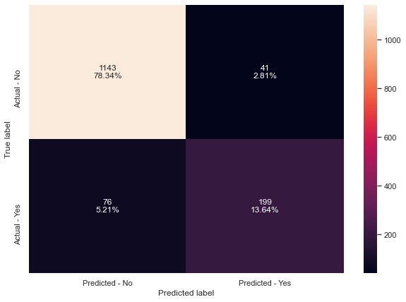

```python
#Calculating different metrics
get_metrics_score(stacking_classifier)

#Creating confusion matrix
make_confusion_matrix(stacking_classifier,y_test)
```

### Observation

1. There is overfitting in all stacking_classifier metrics.
2. There is an increase in the True Positive

```python
# defining list of models
models = [abc, abc_tuned, gbc, gbc_init, gbc_tuned, xgb, xgb_tuned]

# defining empty lists to add train and test results
acc_train = []
acc_test = []
recall_train = []
recall_test = []
precision_train = []
precision_test = []
f1_train = []
f1_test = []

# looping through all the models to get the accuracy, precall and precision scores
for model in models:
    j = get_metrics_score(model,False)
    acc_train.append(np.round(j[0],2))
    acc_test.append(np.round(j[1],2))
    recall_train.append(np.round(j[2],2))
    recall_test.append(np.round(j[3],2))
    precision_train.append(np.round(j[4],2))
    precision_test.append(np.round(j[5],2))
    f1_train.append(np.round(j[6],2))
    f1_test.append(np.round(j[7],2))
```

```python
comparison_frame = pd.DataFrame({'Model':['AdaBoost with default paramters','AdaBoost Tuned',
                                          'Gradient Boosting with default parameters','Gradient Boosting with init=AdaBoost',
                                          'Gradient Boosting Tuned','XGBoost with default parameters','XGBoost Tuned'],
                                          'Train_Accuracy': acc_train,'Test_Accuracy': acc_test,
                                          'Train_Recall':recall_train,'Test_Recall':recall_test,
                                          'Train_Precision':precision_train,'Test_Precision':precision_test,
                                          'Train_F1':f1_train,'Test_F1':f1_test})
comparison_frame
```

|  | Model | Train_Accuracy | Test_Accuracy | Train_Recall | Test_Recall | Train_Precision | Test_Precision | Train_F1 | Test_F1 |
| --- | --- | --- | --- | --- | --- | --- | --- | --- | --- |
| 0 | AdaBoost with default paramters | 0.85 | 0.85 | 0.34 | 0.38 | 0.73 | 0.71 | 0.46 | 0.49 |
| 1 | AdaBoost Tuned | 0.82 | 0.82 | 0.03 | 0.05 | 0.92 | 0.93 | 0.07 | 0.10 |
| 2 | Gradient Boosting with default parameters | 0.89 | 0.87 | 0.46 | 0.41 | 0.88 | 0.81 | 0.60 | 0.55 |
| 3 | Gradient Boosting with init=AdaBoost | 0.89 | 0.87 | 0.45 | 0.41 | 0.89 | 0.83 | 0.60 | 0.55 |
| 4 | Gradient Boosting Tuned | 0.84 | 0.84 | 0.17 | 0.17 | 0.90 | 0.81 | 0.28 | 0.28 |
| 5 | XGBoost with default parameters | 1.00 | 0.93 | 1.00 | 0.74 | 1.00 | 0.88 | 1.00 | 0.80 |
| 6 | XGBoost Tuned | 0.97 | 0.91 | 0.87 | 0.61 | 1.00 | 0.86 | 0.93 | 0.71 |

## Recommendation

1. The sales personnel should target customers with higher income as they will be able to afford the wellness package.
2. The Younger demographic should continue to be a target but to expand the market the sales personnel should break into the middle age who earn above 21,000.
3. Its taking the sale personnel a long duration to pitch the new product. It will b e recommended to go back to the drawing table and rebrand and repackage the wellness product to be more attractive to customers within a few minutes.
4. The affordability should still be a fact that should be looked into and target the required market that can afford it as marketing resources are limited
5. The wellness package should also be made available within the country for those who do not have International passport to travel.
6. The wellness package should be recommended for company retreats and group bonding session as organization in recent times take the physical and mental wellbeing of their employee a priority, this will drawing the necessary income and designation to purchase the new wellness package.